# ExtraaLearn Project

## Context

The EdTech industry has been surging in the past decade immensely, and according to a forecast, the Online Education market would be worth $286.62bn by 2023 with a compound annual growth rate (CAGR) of 10.26% from 2018 to 2023. The modern era of online education has enforced a lot in its growth and expansion beyond any limit. Due to having many dominant features like ease of information sharing, personalized learning experience, transparency of assessment, etc, it is now preferable to traditional education.

In the present scenario due to the Covid-19, the online education sector has witnessed rapid growth and is attracting a lot of new customers. Due to this rapid growth, many new companies have emerged in this industry. With the availability and ease of use of digital marketing resources, companies can reach out to a wider audience with their offerings. The customers who show interest in these offerings are termed as leads. There are various sources of obtaining leads for Edtech companies, like

- The customer interacts with the marketing front on social media or other online platforms.
- The customer browses the website/app and downloads the brochure
- The customer connects through emails for more information.

The company then nurtures these leads and tries to convert them to paid customers. For this, the representative from the organization connects with the lead on call or through email to share further details.

## Objective

ExtraaLearn is an initial stage startup that offers programs on cutting-edge technologies to students and professionals to help them upskill/reskill. With a large number of leads being generated on a regular basis, one of the issues faced by ExtraaLearn is to identify which of the leads are more likely to convert so that they can allocate resources accordingly. You, as a data scientist at ExtraaLearn, have been provided the leads data to:

- Analyze and build an ML model to help identify which leads are more likely to convert to paid customers,
- Find the factors driving the lead conversion process
- Create a profile of the leads which are likely to convert

## Data Description

The data contains the different attributes of leads and their interaction details with ExtraaLearn. The detailed data dictionary is given below.

**Data Dictionary**

- ID: ID of the lead
- age: Age of the lead
- current_occupation: Current occupation of the lead. Values include 'Professional','Unemployed',and 'Student'
- first_interaction: How did the lead first interacted with ExtraaLearn. Values include 'Website', 'Mobile App'
- profile_completed: What percentage of profile has been filled by the lead on the website/mobile app. Values include Low - (0-50%), Medium - (50-75%), High (75-100%)
- website_visits: How many times has a lead visited the website
- time_spent_on_website: Total time spent on the website
- page_views_per_visit: Average number of pages on the website viewed during the visits.
- last_activity: Last interaction between the lead and ExtraaLearn.
  - Email Activity: Seeking for details about program through email, Representative shared information with lead like brochure of program , etc
  - Phone Activity: Had a Phone Conversation with representative, Had conversation over SMS with representative, etc
  - Website Activity: Interacted on live chat with representative, Updated profile on website, etc
- print_media_type1: Flag indicating whether the lead had seen the ad of ExtraaLearn in the Newspaper.
- print_media_type2: Flag indicating whether the lead had seen the ad of ExtraaLearn in the Magazine.
- digital_media: Flag indicating whether the lead had seen the ad of ExtraaLearn on the digital platforms.
- educational_channels: Flag indicating whether the lead had heard about ExtraaLearn in the education channels like online forums, discussion threads, educational websites, etc.
- referral: Flag indicating whether the lead had heard about ExtraaLearn through reference.
- status: Flag indicating whether the lead was converted to a paid customer or not.

## Importing necessary libraries and data

```python
import warnings

warnings.filterwarnings("ignore")
from statsmodels.tools.sm_exceptions import ConvergenceWarning

warnings.simplefilter("ignore", ConvergenceWarning)

# Libraries to help with reading and manipulating data

import pandas as pd
import numpy as np

# To scale the data using z-score
from sklearn.preprocessing import StandardScaler

# Library to split data
from sklearn.model_selection import train_test_split

# libaries to help with data visualization
import matplotlib.pyplot as plt
import seaborn as sns

# Removes the limit for the number of displayed columns
pd.set_option("display.max_columns", None)
# Sets the limit for the number of displayed rows
pd.set_option("display.max_rows", 200)
# setting the precision of floating numbers to 5 decimal points
pd.set_option("display.float_format", lambda x: "%.5f" % x)

# To build model for prediction
import statsmodels.stats.api as sms
from statsmodels.stats.outliers_influence import variance_inflation_factor
import statsmodels.api as sm
from statsmodels.tools.tools import add_constant
from sklearn.linear_model import LogisticRegression
from sklearn.tree import DecisionTreeClassifier
from sklearn import tree
from sklearn.ensemble import RandomForestClassifier

# To tune different models
from sklearn.model_selection import GridSearchCV


# To get diferent metric scores
import sklearn.metrics as metrics
from sklearn.metrics import (
    f1_score,
    accuracy_score,
    recall_score,
    precision_score,
    confusion_matrix,
    classification_report,
    roc_auc_score,
    precision_recall_curve,
    roc_curve,
    make_scorer,
)
```

```python
ext_learn_data = pd.read_csv('/content/ExtraaLearn.csv')
```

```python
ext_learn_data
```

|  | ID | age | current_occupation | first_interaction | profile_completed | website_visits | time_spent_on_website | page_views_per_visit | last_activity | print_media_type1 | print_media_type2 | digital_media | educational_channels | referral | status |
| --- | --- | --- | --- | --- | --- | --- | --- | --- | --- | --- | --- | --- | --- | --- | --- |
| 0 | EXT001 | 57 | Unemployed | Website | High | 7 | 1639 | 1.86100 | Website Activity | Yes | No | Yes | No | No | 1 |
| 1 | EXT002 | 56 | Professional | Mobile App | Medium | 2 | 83 | 0.32000 | Website Activity | No | No | No | Yes | No | 0 |
| 2 | EXT003 | 52 | Professional | Website | Medium | 3 | 330 | 0.07400 | Website Activity | No | No | Yes | No | No | 0 |
| 3 | EXT004 | 53 | Unemployed | Website | High | 4 | 464 | 2.05700 | Website Activity | No | No | No | No | No | 1 |
| 4 | EXT005 | 23 | Student | Website | High | 4 | 600 | 16.91400 | Email Activity | No | No | No | No | No | 0 |
| ... | ... | ... | ... | ... | ... | ... | ... | ... | ... | ... | ... | ... | ... | ... | ... |
| 4607 | EXT4608 | 35 | Unemployed | Mobile App | Medium | 15 | 360 | 2.17000 | Phone Activity | No | No | No | Yes | No | 0 |
| 4608 | EXT4609 | 55 | Professional | Mobile App | Medium | 8 | 2327 | 5.39300 | Email Activity | No | No | No | No | No | 0 |
| 4609 | EXT4610 | 58 | Professional | Website | High | 2 | 212 | 2.69200 | Email Activity | No | No | No | No | No | 1 |
| 4610 | EXT4611 | 57 | Professional | Mobile App | Medium | 1 | 154 | 3.87900 | Website Activity | Yes | No | No | No | No | 0 |
| 4611 | EXT4612 | 55 | Professional | Website | Medium | 4 | 2290 | 2.07500 | Phone Activity | No | No | No | No | No | 0 |

4612 rows × 15 columns

## Data Overview

- Observations
- Sanity checks

```python
ext_learn_data.shape
```

```
(4612, 15)
```

```python
ext_learn_data.head()
```

|  | ID | age | current_occupation | first_interaction | profile_completed | website_visits | time_spent_on_website | page_views_per_visit | last_activity | print_media_type1 | print_media_type2 | digital_media | educational_channels | referral | status |
| --- | --- | --- | --- | --- | --- | --- | --- | --- | --- | --- | --- | --- | --- | --- | --- |
| 0 | EXT001 | 57 | Unemployed | Website | High | 7 | 1639 | 1.86100 | Website Activity | Yes | No | Yes | No | No | 1 |
| 1 | EXT002 | 56 | Professional | Mobile App | Medium | 2 | 83 | 0.32000 | Website Activity | No | No | No | Yes | No | 0 |
| 2 | EXT003 | 52 | Professional | Website | Medium | 3 | 330 | 0.07400 | Website Activity | No | No | Yes | No | No | 0 |
| 3 | EXT004 | 53 | Unemployed | Website | High | 4 | 464 | 2.05700 | Website Activity | No | No | No | No | No | 1 |
| 4 | EXT005 | 23 | Student | Website | High | 4 | 600 | 16.91400 | Email Activity | No | No | No | No | No | 0 |

```python
ext_learn_data.dtypes
```

|  | 0 |
| --- | --- |
| ID | object |
| age | int64 |
| current_occupation | object |
| first_interaction | object |
| profile_completed | object |
| website_visits | int64 |
| time_spent_on_website | int64 |
| page_views_per_visit | float64 |
| last_activity | object |
| print_media_type1 | object |
| print_media_type2 | object |
| digital_media | object |
| educational_channels | object |
| referral | object |
| status | int64 |

**dtype:** object

```python
ext_learn_data.info()
```

```
<class 'pandas.core.frame.DataFrame'>
RangeIndex: 4612 entries, 0 to 4611
Data columns (total 15 columns):
 #   Column                 Non-Null Count  Dtype
---  ------                 --------------  -----
 0   ID                     4612 non-null   object
 1   age                    4612 non-null   int64
 2   current_occupation     4612 non-null   object
 3   first_interaction      4612 non-null   object
 4   profile_completed      4612 non-null   object
 5   website_visits         4612 non-null   int64
 6   time_spent_on_website  4612 non-null   int64
 7   page_views_per_visit   4612 non-null   float64
 8   last_activity          4612 non-null   object
 9   print_media_type1      4612 non-null   object
 10  print_media_type2      4612 non-null   object
 11  digital_media          4612 non-null   object
 12  educational_channels   4612 non-null   object
 13  referral               4612 non-null   object
 14  status                 4612 non-null   int64
dtypes: float64(1), int64(4), object(10)
memory usage: 540.6+ KB
```

```python
ext_learn_data.describe()
```

|  | age | website_visits | time_spent_on_website | page_views_per_visit | status |
| --- | --- | --- | --- | --- | --- |
| count | 4612.00000 | 4612.00000 | 4612.00000 | 4612.00000 | 4612.00000 |
| mean | 46.20121 | 3.56678 | 724.01127 | 3.02613 | 0.29857 |
| std | 13.16145 | 2.82913 | 743.82868 | 1.96812 | 0.45768 |
| min | 18.00000 | 0.00000 | 0.00000 | 0.00000 | 0.00000 |
| 25% | 36.00000 | 2.00000 | 148.75000 | 2.07775 | 0.00000 |
| 50% | 51.00000 | 3.00000 | 376.00000 | 2.79200 | 0.00000 |
| 75% | 57.00000 | 5.00000 | 1336.75000 | 3.75625 | 1.00000 |
| max | 63.00000 | 30.00000 | 2537.00000 | 18.43400 | 1.00000 |

```python
object_col = list(['current_occupation','first_interaction','profile_completed',
                'last_activity','print_media_type1','print_media_type2','digital_media','educational_channels','referral','status'])

numerical_col = list(['age','website_visits','time_spent_on_website',
                'page_views_per_visit'])


for i in object_col:
    print(ext_learn_data[i].value_counts(normalize=True))
    print('--------')
```

```
current_occupation
Professional   0.56722
Unemployed     0.31245
Student        0.12034
Name: proportion, dtype: float64
--------
first_interaction
Website      0.55117
Mobile App   0.44883
Name: proportion, dtype: float64
--------
profile_completed
High     0.49089
Medium   0.48591
Low      0.02320
Name: proportion, dtype: float64
--------
last_activity
Email Activity     0.49393
Phone Activity     0.26756
Website Activity   0.23851
Name: proportion, dtype: float64
--------
print_media_type1
No    0.89224
Yes   0.10776
Name: proportion, dtype: float64
--------
print_media_type2
No    0.94948
Yes   0.05052
Name: proportion, dtype: float64
--------
digital_media
No    0.88573
Yes   0.11427
Name: proportion, dtype: float64
--------
educational_channels
No    0.84714
Yes   0.15286
Name: proportion, dtype: float64
--------
referral
No    0.97984
Yes   0.02016
Name: proportion, dtype: float64
--------
status
0   0.70143
1   0.29857
Name: proportion, dtype: float64
--------
```

```python
ext_learn_data.nunique()
```

|  | 0 |
| --- | --- |
| ID | 4612 |
| age | 46 |
| current_occupation | 3 |
| first_interaction | 2 |
| profile_completed | 3 |
| website_visits | 27 |
| time_spent_on_website | 1623 |
| page_views_per_visit | 2414 |
| last_activity | 3 |
| print_media_type1 | 2 |
| print_media_type2 | 2 |
| digital_media | 2 |
| educational_channels | 2 |
| referral | 2 |
| status | 2 |

**dtype:** int64

##### **Observations:**

- total of 4612 rows present with 15 columns
- most columns are of object datatype with only age, website visits, time spent on website as int values and pages view per visit as float values
- the final status column is also int
- there are no missing values in any of the col
- more than 50% of users are professionals with 30% being unemployeed
- almost 50-50% of users has their first interaction through website or morbile app
- 49% of users have high profile completetion and 48.5% have medium profile completetion
- last activity on email is highest with 50% getting attributed followed by phone and website at 26% and 24% respectively
- interection through educational_channels and digital_media is the highest at 15% and 11% of total users
- Only 2% came through referrals
- 70% of users are not potential customers while 30% of them are
- 6 factors fields consist only two unique values as their outcomes

## Exploratory Data Analysis (EDA)

- EDA is an important part of any project involving data.
- It is important to investigate and understand the data better before building a model with it.
- A few questions have been mentioned below which will help you approach the analysis in the right manner and generate insights from the data.
- A thorough analysis of the data, in addition to the questions mentioned below, should be done.

**Questions**

1. Leads will have different expectations from the outcome of the course and the current occupation may play a key role in getting them to participate in the program. Find out how current occupation affects lead status.
2. The company's first impression on the customer must have an impact. Do the first channels of interaction have an impact on the lead status?
3. The company uses multiple modes to interact with prospects. Which way of interaction works best?
4. The company gets leads from various channels such as print media, digital media, referrals, etc. Which of these channels have the highest lead conversion rate?
5. People browsing the website or mobile application are generally required to create a profile by sharing their personal data before they can access additional information.Does having more details about a prospect increase the chances of conversion?

```python
ext_learn_data[numerical_col].describe()
```

|  | age | website_visits | time_spent_on_website | page_views_per_visit |
| --- | --- | --- | --- | --- |
| count | 4612.00000 | 4612.00000 | 4612.00000 | 4612.00000 |
| mean | 46.20121 | 3.56678 | 724.01127 | 3.02613 |
| std | 13.16145 | 2.82913 | 743.82868 | 1.96812 |
| min | 18.00000 | 0.00000 | 0.00000 | 0.00000 |
| 25% | 36.00000 | 2.00000 | 148.75000 | 2.07775 |
| 50% | 51.00000 | 3.00000 | 376.00000 | 2.79200 |
| 75% | 57.00000 | 5.00000 | 1336.75000 | 3.75625 |
| max | 63.00000 | 30.00000 | 2537.00000 | 18.43400 |

##### **Observations:**

- time spent on the website may contain outliers since there is a huge variation between the mean (724) and the median (376) of the time data column
- std for both website visits and pages views per visit suggest concentration but their max values are exteme

```python
print(ext_learn_data['ID'].nunique())
print(ext_learn_data.shape)
```

```
4612
(4612, 15)
```

```python
# dropping the column ID since there are no repeated values or categorical input there
ext_learn_data.drop(columns='ID',inplace=True)
```

```python
# Doing univariant analysis for the given data
# Will be plotting histogram first for the numerical columns
# doing box plot could be the next step to identify outliers or any other interesting facts
```

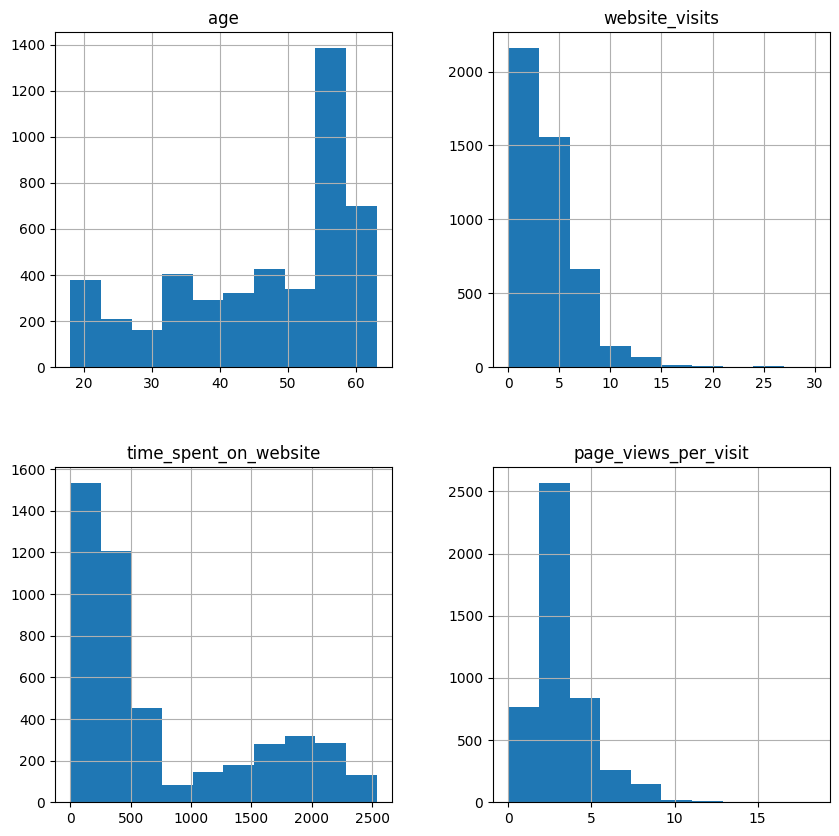

```python
ext_learn_data[numerical_col].hist(figsize=(10,10))
plt.show()
```

##### **Observations:**

- age is left skewed
- website visits, time spent on website are clear right skewed
- pages visit per website visit is distributed in more normal way but is still right skewed a bit
- most users are in the older ages
- most users visit website pretty less and spent less time on website

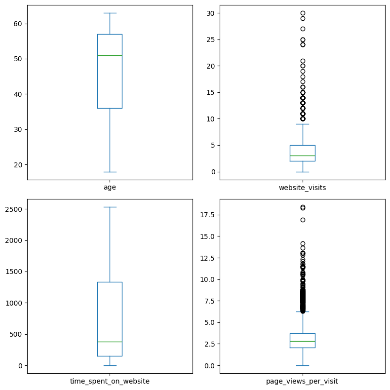

```python
ext_learn_data[numerical_col].plot(kind='box', subplots=True, layout=(2, 2), figsize=(8, 8), sharex=False, sharey=False)
plt.tight_layout()
plt.show()
```

###### **Observations:**

- There are no outliers in in age distribution
- Many outliers in the website visits, most users visits website from 0 to 7 times
- No visible outliers for time spent on the website but range is very wide even though median is at the bottom
- Many outliers in the pages viewed per visit, most users view 0 to 6 pages per visit
- Outlier treatment might be required for website visits and pages viewed per visit

```python
# Moving ahead with the bivariant and/or multivariant analysis

ext_learn_data.head()
```

|  | age | current_occupation | first_interaction | profile_completed | website_visits | time_spent_on_website | page_views_per_visit | last_activity | print_media_type1 | print_media_type2 | digital_media | educational_channels | referral | status |
| --- | --- | --- | --- | --- | --- | --- | --- | --- | --- | --- | --- | --- | --- | --- |
| 0 | 57 | Unemployed | Website | High | 7 | 1639 | 1.86100 | Website Activity | Yes | No | Yes | No | No | 1 |
| 1 | 56 | Professional | Mobile App | Medium | 2 | 83 | 0.32000 | Website Activity | No | No | No | Yes | No | 0 |
| 2 | 52 | Professional | Website | Medium | 3 | 330 | 0.07400 | Website Activity | No | No | Yes | No | No | 0 |
| 3 | 53 | Unemployed | Website | High | 4 | 464 | 2.05700 | Website Activity | No | No | No | No | No | 1 |
| 4 | 23 | Student | Website | High | 4 | 600 | 16.91400 | Email Activity | No | No | No | No | No | 0 |

```python
# object_col
```

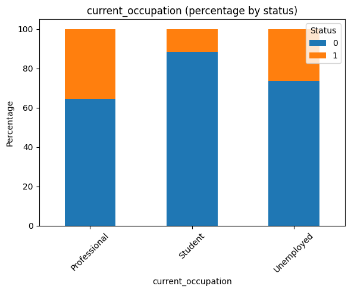

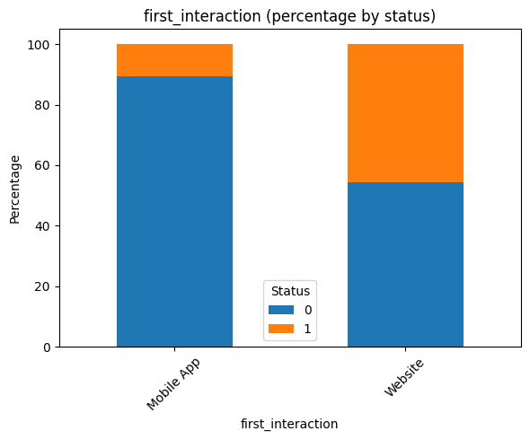

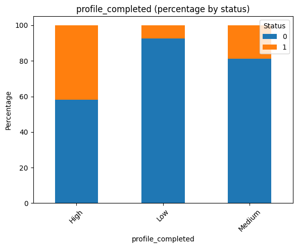

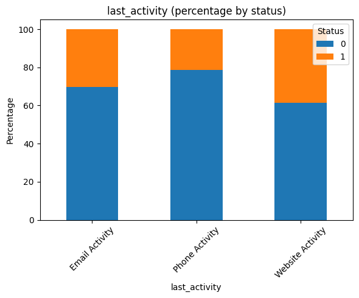

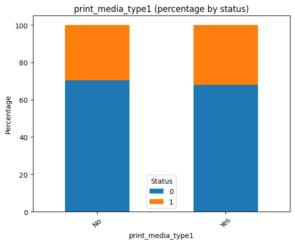

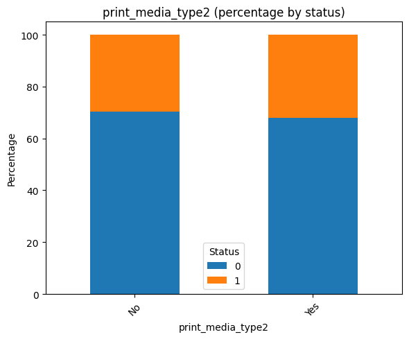

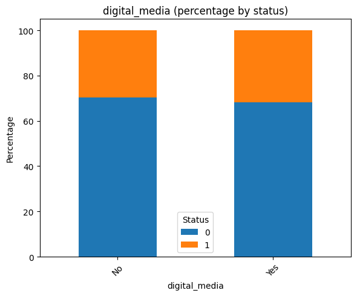

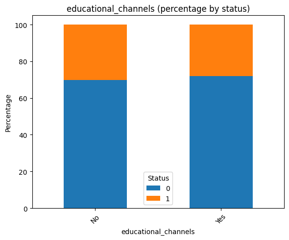

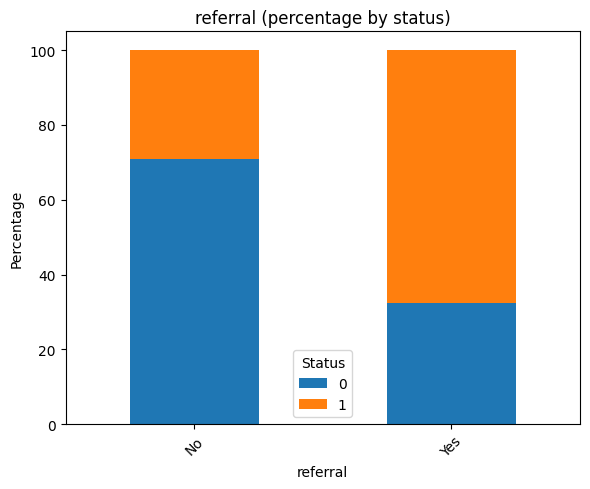

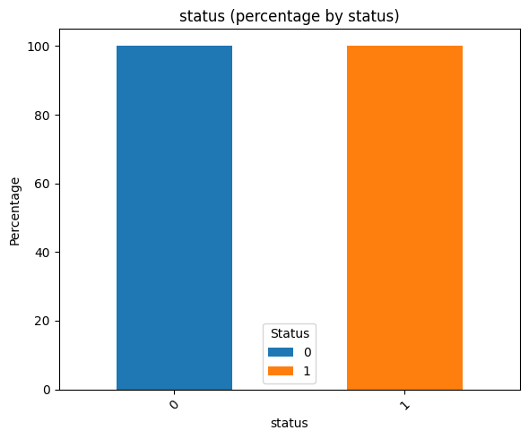

```python
# Bivariant analysis for the categorical variables

for i in object_col:
    cross = pd.crosstab(ext_learn_data[i], ext_learn_data['status'], normalize='index') * 100

    cross.plot(kind='bar', stacked=True, figsize=(6, 5))
    plt.title(f'{i} (percentage by status)')
    plt.xlabel(i)
    plt.ylabel('Percentage')
    plt.xticks(rotation=45)
    plt.legend(title='Status')
    plt.tight_layout()
    plt.show()
```

##### **Oveservations:**

- Professionals have a higher % of getting a conversion followed by unemployed
- First interaction through website generate higher conversions
- Users who have higher profle completition have higher chances of getting converted
- Website and Email activity have higher conversion rates
- Referrals also drive a higher rate of success/conversions
- No visible differences for print media, digital media and educational channels

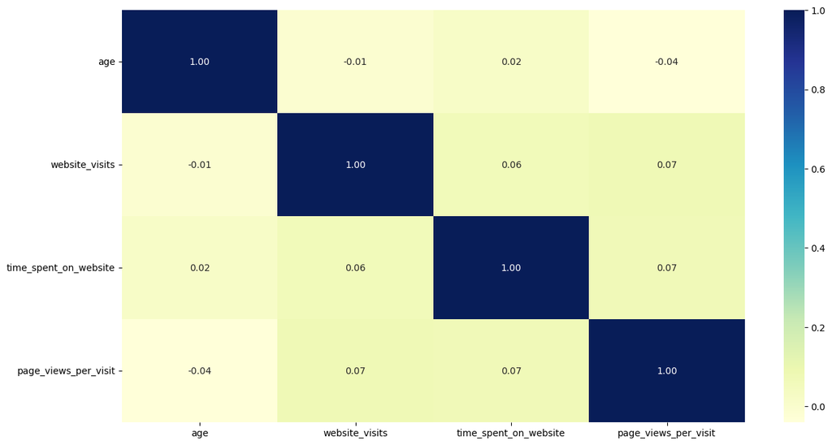

```python
# Plotting the correlation between numerical variables

plt.figure(figsize=(15,8))
sns.heatmap(ext_learn_data[numerical_col].corr(),annot=True, fmt='0.2f', cmap='YlGnBu')
```

#### **Observations:**

- a visible correlation by not a strong one can be formed between pages viewed per visit and website visits and pages viewed per visit and time spent on website

## Data Preprocessing

- Missing value treatment (if needed) :: *there are no missing values in the data*
- Feature engineering (if needed)
- Outlier detection and treatment (if needed) :: *since we are using random forest and decision tree for modelling, outlier treatment is not needed*
- Preparing data for modeling
- Any other preprocessing steps (if needed)

```python
ext_learn_data.head()
```

|  | age | current_occupation | first_interaction | profile_completed | website_visits | time_spent_on_website | page_views_per_visit | last_activity | print_media_type1 | print_media_type2 | digital_media | educational_channels | referral | status |
| --- | --- | --- | --- | --- | --- | --- | --- | --- | --- | --- | --- | --- | --- | --- |
| 0 | 57 | Unemployed | Website | High | 7 | 1639 | 1.86100 | Website Activity | Yes | No | Yes | No | No | 1 |
| 1 | 56 | Professional | Mobile App | Medium | 2 | 83 | 0.32000 | Website Activity | No | No | No | Yes | No | 0 |
| 2 | 52 | Professional | Website | Medium | 3 | 330 | 0.07400 | Website Activity | No | No | Yes | No | No | 0 |
| 3 | 53 | Unemployed | Website | High | 4 | 464 | 2.05700 | Website Activity | No | No | No | No | No | 1 |
| 4 | 23 | Student | Website | High | 4 | 600 | 16.91400 | Email Activity | No | No | No | No | No | 0 |

```python
ext_learn_data_model = ext_learn_data.copy()
```

```python
ext_learn_data.head()
```

|  | age | current_occupation | first_interaction | profile_completed | website_visits | time_spent_on_website | page_views_per_visit | last_activity | print_media_type1 | print_media_type2 | digital_media | educational_channels | referral | status |
| --- | --- | --- | --- | --- | --- | --- | --- | --- | --- | --- | --- | --- | --- | --- |
| 0 | 57 | Unemployed | Website | High | 7 | 1639 | 1.86100 | Website Activity | Yes | No | Yes | No | No | 1 |
| 1 | 56 | Professional | Mobile App | Medium | 2 | 83 | 0.32000 | Website Activity | No | No | No | Yes | No | 0 |
| 2 | 52 | Professional | Website | Medium | 3 | 330 | 0.07400 | Website Activity | No | No | Yes | No | No | 0 |
| 3 | 53 | Unemployed | Website | High | 4 | 464 | 2.05700 | Website Activity | No | No | No | No | No | 1 |
| 4 | 23 | Student | Website | High | 4 | 600 | 16.91400 | Email Activity | No | No | No | No | No | 0 |

```python
to_get_dummies_for = ['current_occupation', 'first_interaction','profile_completed', 'last_activity']


ext_learn_data_model = pd.get_dummies(data = ext_learn_data_model, columns = to_get_dummies_for,drop_first=True)

#converting yes/no to integers
dict_print_media_type1 = {'Yes': 1, 'No':0}
dict_print_media_type2 = {'Yes': 1, 'No': 0}
dict_digital_media = {'Yes': 1, 'No': 0}
dict_educational_channels = {'Yes': 1, 'No': 0}
dict_referral = {'Yes': 1, 'No': 0}


ext_learn_data_model['print_media_type1'] = ext_learn_data_model.print_media_type1.map(dict_print_media_type1)
ext_learn_data_model['print_media_type2'] = ext_learn_data_model.print_media_type2.map(dict_print_media_type2)
ext_learn_data_model['digital_media'] = ext_learn_data_model.digital_media.map(dict_digital_media)
ext_learn_data_model['educational_channels'] = ext_learn_data_model.educational_channels.map(dict_educational_channels)
ext_learn_data_model['referral'] = ext_learn_data_model.referral.map(dict_referral)
```

```python
ext_learn_data_model.columns
```

```
Index(['age', 'website_visits', 'time_spent_on_website',
       'page_views_per_visit', 'print_media_type1', 'print_media_type2',
       'digital_media', 'educational_channels', 'referral', 'status',
       'current_occupation_Student', 'current_occupation_Unemployed',
       'first_interaction_Website', 'profile_completed_Low',
       'profile_completed_Medium', 'last_activity_Phone Activity',
       'last_activity_Website Activity'],
      dtype='object')
```

```python
# Separating target variable and other variables

Y= ext_learn_data_model.status
X= ext_learn_data_model.drop(columns = ['status'])
```

```python
# Splitting the data into 70% train and 30% test set

X_train, X_test, y_train, y_test = train_test_split(X, Y, test_size = 0.3, random_state = 1, stratify = Y)
```

```python
# Feature Scalling using the standar scaler function


sc=StandardScaler()

# scaling train data
X_train_scaled=sc.fit_transform(X_train)
X_train_scaled=pd.DataFrame(X_train_scaled, columns=X.columns)

# scaling test data
X_test_scaled=sc.transform(X_test)
X_test_scaled=pd.DataFrame(X_test_scaled, columns=X.columns)
```

```python
# Before we start with the model building, lets define a function that will help with the evaluation of the performance of the model

# since it a classification model,confusion_matrix with precision and recall for the model on training and test can be good evaluating factors
```

```python
# Creating metric function
def model_score(actual, predicted):
    print(classification_report(actual, predicted))

    cm = confusion_matrix(actual, predicted)
    plt.figure(figsize=(8,5))

    sns.heatmap(cm, annot=True,  fmt='.2f', xticklabels=['not converted', 'converted'], yticklabels=['not converted', 'converted'])
    plt.ylabel('Actual')
    plt.xlabel('Predicted')
    plt.show()
```

## Building a Decision Tree model

```python
# to start with, lets see frequency of each status
print(y_train.value_counts(normalize=True))
print(y_train.value_counts())
```

```
status
0   0.70136
1   0.29864
Name: proportion, dtype: float64
status
0    2264
1     964
Name: count, dtype: int64
```

```python
# as we want for each category to get equal weightage, we will use DecisionTreeClassifier function
# class_weight is a hyperparameter for the decision tree classifier, and in this case,
# we can pass a dictionary {0:0.3, 1:0.7} to the model to specify the weight of each class
# and the decision tree will give more weightage to class 1.

# Class 1 being the converted or status = 1
```

```python
# Building decision tree model
dt = DecisionTreeClassifier(class_weight = {0: 0.3, 1: 0.7}, random_state = 1)
```

```python
# Fitting decision tree model
dt.fit(X_train, y_train)
```

```
DecisionTreeClassifier(class_weight={0: 0.3, 1: 0.7}, random_state=1)
```

```python
# Checking performance on the training dataset
y_train_pred_dt = dt.predict(X_train)

model_score(y_train, y_train_pred_dt)
```

```
              precision    recall  f1-score   support

           0       1.00      1.00      1.00      2264
           1       1.00      1.00      1.00       964

    accuracy                           1.00      3228
   macro avg       1.00      1.00      1.00      3228
weighted avg       1.00      1.00      1.00      3228
```

```
              precision    recall  f1-score   support

           0       0.84      0.86      0.85       971
           1       0.65      0.62      0.64       413

    accuracy                           0.79      1384
   macro avg       0.75      0.74      0.74      1384
weighted avg       0.79      0.79      0.79      1384
```

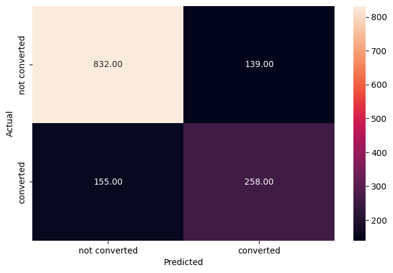

```python
# Checking performance on the testing dataset
y_test_pred_dt = dt.predict(X_test)

model_score(y_test, y_test_pred_dt)
```

## Do we need to prune the tree?

- The Decision tree is giving a **100% score for all metrics on the training dataset.**
- But for the test set, the precison is 65% and recall is at 62%
- this seems like the model is overfitting
- this will not help us to right fully predict the potential customers with precison this low
- We furthet need to prune the decision tree model as this model is overfitting.
- Let us use hyperparameter tuning which might increase the performance of the model
- we will use grid search hyperparameter tuning to tune our model for better results

```python
{0: 0.5, 1: 0.5}
```

```
{0: 0.5, 1: 0.5}
```

```python
# Choose the type of classifier
dtree_estimator = DecisionTreeClassifier(class_weight = {0: 0.3, 1: 0.7}, random_state = 1)

# Grid of parameters to choose from
parameters = {'max_depth': np.arange(3, 21, 2),
              'criterion': ['gini', 'entropy'],
              'min_samples_leaf': [5, 10, 20, 25]
             }

# Type of scoring used to compare parameter combinations
scorer = metrics.make_scorer(precision_score, pos_label = 1)

# Run the grid search
gridCV = GridSearchCV(dtree_estimator, parameters, scoring = scorer, cv = 10)

# Fitting the grid search on the train data
gridCV = gridCV.fit(X_train, y_train)

# Set the classifier to the best combination of parameters
dtree_estimator = gridCV.best_estimator_

# Fit the best estimator to the data
dtree_estimator.fit(X_train, y_train)
```

```
DecisionTreeClassifier(class_weight={0: 0.3, 1: 0.7}, max_depth=np.int64(5),
                       min_samples_leaf=5, random_state=1)
```

```
              precision    recall  f1-score   support

           0       0.95      0.82      0.88      2264
           1       0.68      0.89      0.77       964

    accuracy                           0.84      3228
   macro avg       0.81      0.86      0.83      3228
weighted avg       0.87      0.84      0.85      3228
```

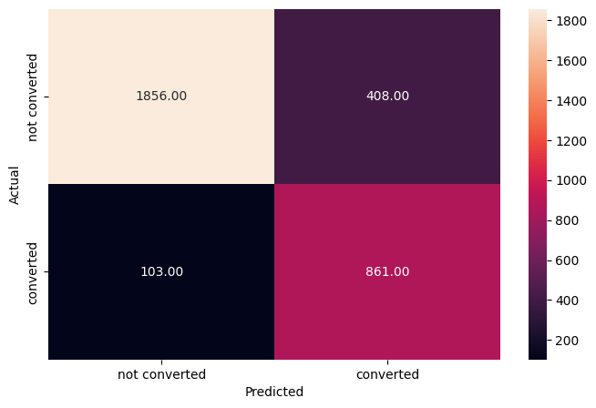

```python
# Checking performance on the training dataset
y_train_pred_dt = dtree_estimator.predict(X_train)

model_score(y_train, y_train_pred_dt)
```

```
              precision    recall  f1-score   support

           0       0.93      0.81      0.87       971
           1       0.66      0.86      0.75       413

    accuracy                           0.83      1384
   macro avg       0.79      0.84      0.81      1384
weighted avg       0.85      0.83      0.83      1384
```

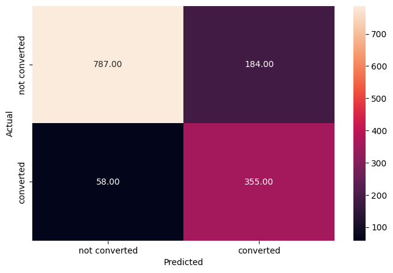

```python
# Checking performance on the test dataset
y_test_pred_dt = dtree_estimator.predict(X_test)

model_score(y_test, y_test_pred_dt)
```

#### **Observation:**

- Even after tuning hyperparamters and using grid search to improve the precision, it did not improve significantly
- let us try the random forest model if that can give better results
- but before that, lets see what are the major factors which affects the conversion of a user as per the tuned decision tree model

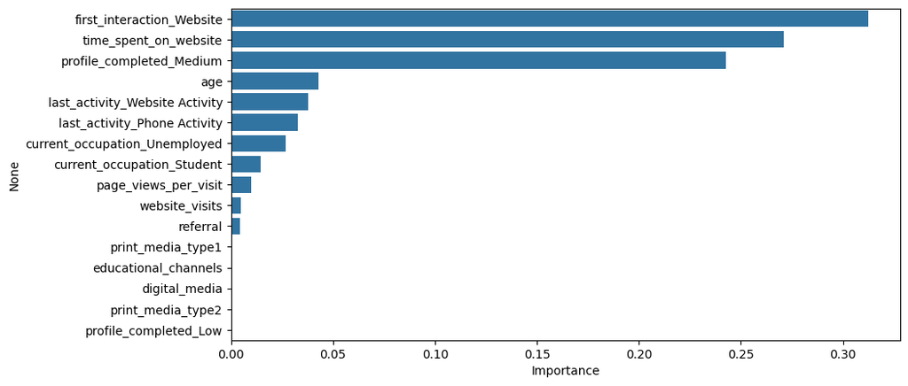

```python
importances = dtree_estimator.feature_importances_

columns = X.columns

importance_df = pd.DataFrame(importances, index = columns, columns = ['Importance']).sort_values(by = 'Importance', ascending = False)

plt.figure(figsize = (10, 5))

sns.barplot(x=importance_df.Importance, y=importance_df.index)
```

#### **Observation:**

- as per the model, first interaction through website, total spent on the website and profile completion plays the major role in conversion of a user

```python
# let us build a random forest model now and lets see if that model can give any better insights or predictiability
```

## Building a Random Forest model

```python
# Fitting the Random Forest classifier on the training data
rf_estimator = RandomForestClassifier(class_weight = {0: 0.3, 1: 0.7}, random_state = 42)

rf_estimator.fit(X_train, y_train)
```

```
RandomForestClassifier(class_weight={0: 0.3, 1: 0.7}, random_state=42)
```

```python
# Checking performance on the training data
y_pred_train_rf = rf_estimator.predict(X_train)

model_score(y_train, y_pred_train_rf)
```

```
              precision    recall  f1-score   support

           0       1.00      1.00      1.00      2264
           1       1.00      1.00      1.00       964

    accuracy                           1.00      3228
   macro avg       1.00      1.00      1.00      3228
weighted avg       1.00      1.00      1.00      3228
```

```
              precision    recall  f1-score   support

           0       0.89      0.93      0.91       971
           1       0.81      0.73      0.76       413

    accuracy                           0.87      1384
   macro avg       0.85      0.83      0.84      1384
weighted avg       0.86      0.87      0.86      1384
```

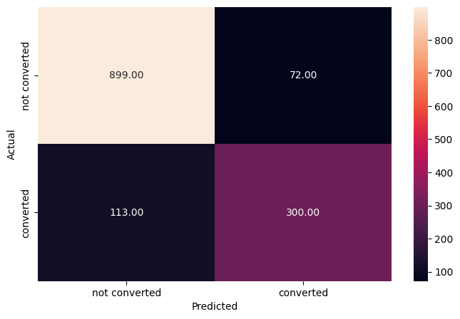

```python
# Checking performance on the test dataset
y_pred_test_rf = rf_estimator.predict(X_test)

model_score(y_test, y_pred_test_rf)
```

#### **Observations**

- Even though the train model is overfitting with 100% precision and 100% recall, 81% precision and 73% recall on test set is actually not as off as it was in the decision tree forest
- But to curb the overfitting we should try pruning and hyperparameter tuning

```python
# Let us see the feature importance as per the random forest model
```

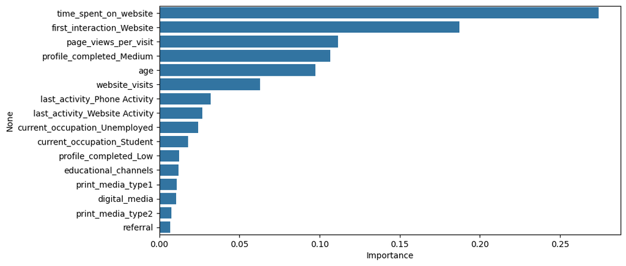

```python
importances = rf_estimator.feature_importances_

columns = X.columns

importance_df = pd.DataFrame(importances, index = columns, columns = ['Importance']).sort_values(by = 'Importance', ascending = False)

plt.figure(figsize = (10, 5))

sns.barplot(x=importance_df.Importance, y=importance_df.index)
```

- we will tune the following parameters of the random forest model to get a better precision: n_estimators, min_samples_leaf, max_features

```python
# Choose the type of classifier
rf_estimator_tuned = RandomForestClassifier(class_weight = {0: 0.3, 1: 0.7}, random_state = 1)

# Grid of parameters to choose from
params_rf = {
        "n_estimators": [70, 35,50],
        "min_samples_leaf": np.arange(1, 7, 1),
        "max_features": [0.7,0.9,0.8,0.5,0.6, 'auto'],
}


# Type of scoring used to compare parameter combinations - recall score for class 1
scorer = metrics.make_scorer(precision_score, pos_label = 1)

# Run the grid search
grid_obj = GridSearchCV(rf_estimator_tuned, params_rf, scoring = scorer, cv = 5)

grid_obj = grid_obj.fit(X_train, y_train)

# Set the classifier to the best combination of parameters
rf_estimator_tuned = grid_obj.best_estimator_
```

```python
rf_estimator_tuned.fit(X_train, y_train)
```

```
RandomForestClassifier(class_weight={0: 0.3, 1: 0.7}, max_features=0.9,
                       min_samples_leaf=np.int64(1), n_estimators=70,
                       random_state=1)
```

```python
# Checking performance on the training data
y_pred_train_rf_tuned = rf_estimator_tuned.predict(X_train)

model_score(y_train, y_pred_train_rf_tuned)
```

```
              precision    recall  f1-score   support

           0       1.00      1.00      1.00      2264
           1       1.00      1.00      1.00       964

    accuracy                           1.00      3228
   macro avg       1.00      1.00      1.00      3228
weighted avg       1.00      1.00      1.00      3228
```

```
              precision    recall  f1-score   support

           0       0.88      0.91      0.90       971
           1       0.78      0.71      0.74       413

    accuracy                           0.85      1384
   macro avg       0.83      0.81      0.82      1384
weighted avg       0.85      0.85      0.85      1384
```

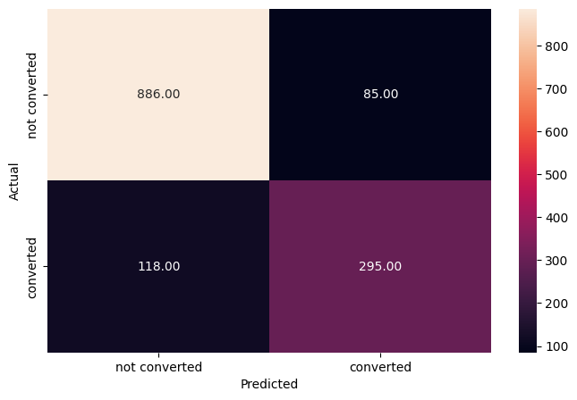

```python
# Checking performance on the test dataset
y_test_pred_rf = rf_estimator_tuned.predict(X_test)

model_score(y_test, y_test_pred_rf)
```

## Do we need to prune the tree?

- Since the precision does not increase even after pruning the tree, the pruning of tree is not required in the random forest model

#### **Observations:**

- Random forest without pruning is the best fitting model here with 81% precision and 73% recall for the class 1 or converted = 1
- Time spent on website and first time interaction with website are the best levers to increase then user conversion

## Actionable Insights and Recommendations

**Here are the top 5 Data insights around conversion as per the above analysis:**

1. The longer a user stays on your website, the more likely they are to convert.
2. Users who first land on your website — rather than an app tend to be more serious.
3. The more pages someone browses during a visit, the higher the chance they’ll convert.
4. Users who take the time to fill out more of their profile are more likely to follow through.
5. People who are a bit older or who’ve visited before are more likely to convert.

**Here the top 5 actionable recommendations to increase conversion and reduce revenue loss:**

1. Introduce Time-on-Site Triggers, if a user spent certain amount of time on the website, trigger a chatbot or email
2. Prioritize Website-Focused Journeys over mobile app journey
3. Score and Prioritize Leads Based on Engagement, website engagement can be the first to get into the pipeline
4. Remove or Simplify Low-Impact Channels like print_media, digital media and educational channels
5. Push for referrals since there is higher conversion from them but still only a very small amount of users use them